# Complement C3

Fold-switch pair **3l5nB_2a73B** — **3l5nB** vs **2a73B**

Homo sapiens

## Figure 1: Phylogenetic tree with per-cluster fold-preference heatmap.

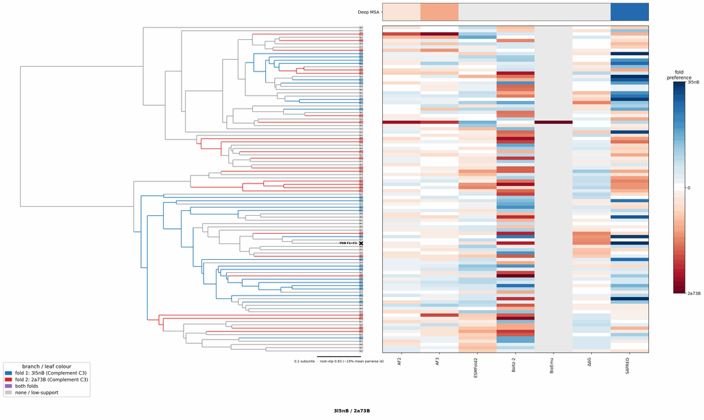

## Figure 2: Aligned overlay (both folds superposed)

The single fold-switching chain of each fold superposed by TM-align; waters hidden, any ligand shown as green sticks. Grey = structurally conserved core, colour = divergent (fold-switching) region.

3l5nB (Complement C3) · trimer2a73B (Complement C3) · dimerLigand MAN|NAG (bound to 3l5nB), Ligand BMA|MAN|NAG (bound to 2a73B)

TM-score: 0.302 · Trigger class: ligand

Aligned overlay

Loading...

## Figure 3: The two folds, side by side

Each fold is coloured by per-residue Cα deviation between the two superposed structures: grey ≈ conserved core, full colour = structurally divergent (fold-switching) region.

3l5nB (Complement C3)

2a73B (Complement C3)

0 Å5≥10 Å

3l5nB (Complement C3)

Loading...

2a73B (Complement C3)

Loading...

## Figure 4: Best-cluster predicted contact maps over the two true folds.

Predicted contact maps (MSA-Transformer) for the clusters best matching each fold, over the true contacts of fold 1 (upper triangle) and fold 2 (lower). Divergent contacts between clusters are the contact-level signature of fold-switching.

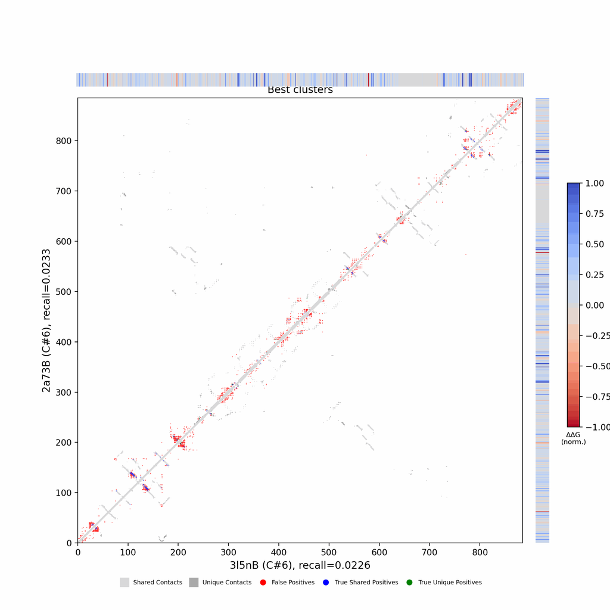

## Figure 5: Per-residue ΔΔG fold-preference contribution

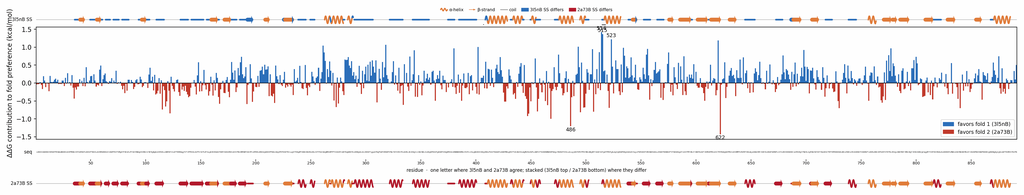

**More figures**

## Figure 6: Deep-MSA contact map panel / Best clusters contact map panel

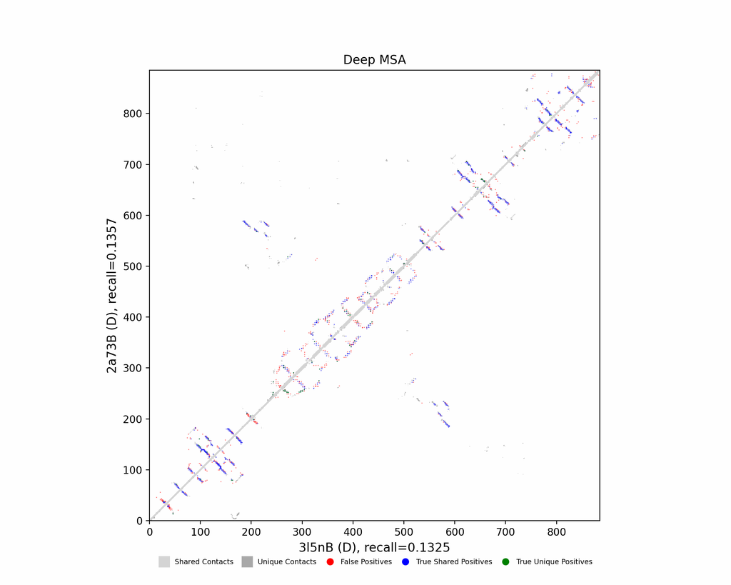

Deep-MSA contact map panel

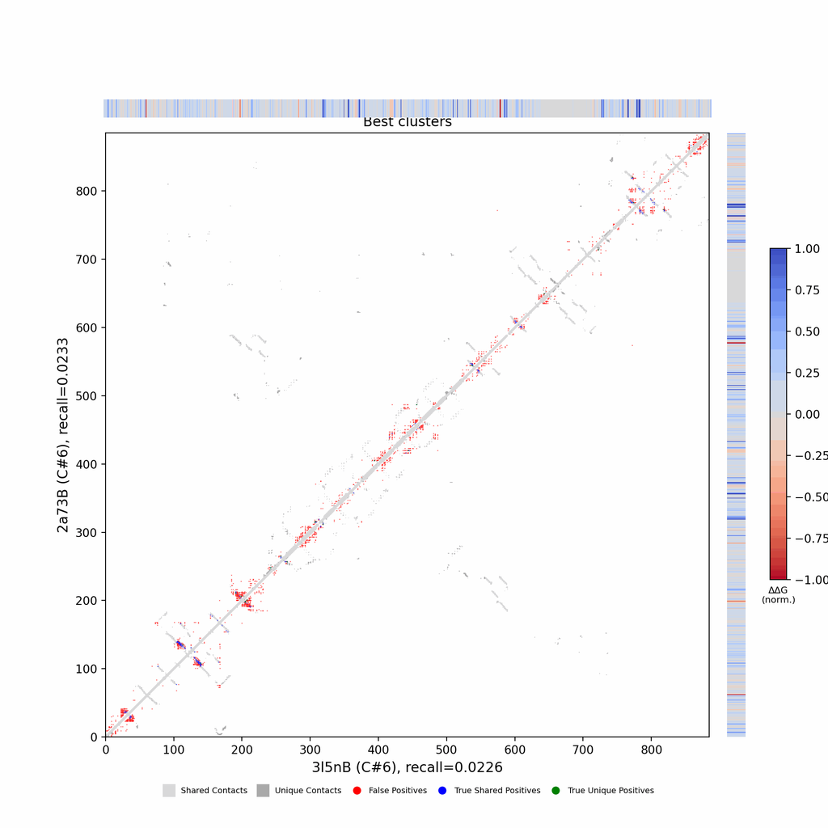

Best clusters contact map panel

## Figure 7: All clusters contact-map mosaic (small multiples).

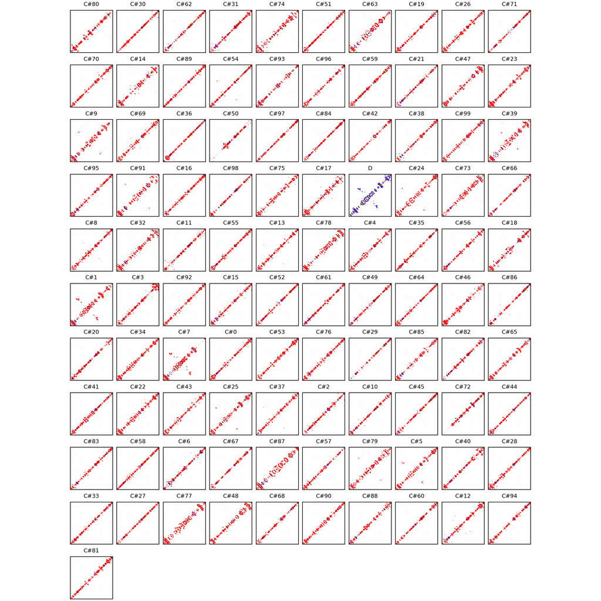

## Figure 8: Phylo null: tree with shuffled cluster fold labels.

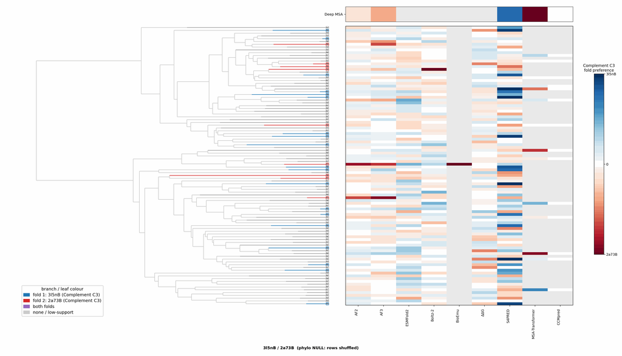

## Cluster metrics table

Per-cluster metrics underlying the figures above.

| cluster | n | neff | AF2_TM1 | AF2_TM2 | AF3_TM1 | AF3_TM2 | RE-MSAT-COM | RE-MSAT1 | RE-MSAT2 | ESM_SEQIDS | ESM_TM1 | ESM_TM2 | ΔΔG_Bias | ΔΔG_Bias_std | ΔΔG_frac_F1 | Boltz2_pref | S4PRED_pref | CCMpred_pref | BioEmu_pref |
| --- | --- | --- | --- | --- | --- | --- | --- | --- | --- | --- | --- | --- | --- | --- | --- | --- | --- | --- | --- |
| Deep | - | - | 0.56 | 0.6 | 0.55 | 0.7 | 0.44 | 0.39 | 0.39 | - | - | - | - | - | - | - | 0.09 | 0.0 | - |
| 000 | 362.0 | 105.0 | 0.3 | 0.27 | 0.38 | 0.28 | 0.0 | 0.0 | 0.0 | 008; 008; 002; 002; 009; 009; 005; 005; 006; 006 | 0.36 ± 0.02 | 0.63 ± 0.03 | 59.12 | 15.11 | 1.0 | -0.06 | -0.03 | 0.0 | - |
| 001 | 192.0 | 112.0 | 0.24 | 0.35 | 0.3 | 0.43 | 0.02 | 0.03 | 0.02 | 001; 005; 001; 009; 004; 002; 002; 006; 003; 003 | 0.35 ± 0.06 | 0.52 ± 0.15 | 92.11 | 34.33 | 1.0 | -0.09 | -0.01 | 0.0 | - |
| 002 | 185.0 | 57.0 | 0.15 | 0.17 | 0.34 | 0.28 | 0.0 | 0.0 | 0.0 | 001; 006; 003; 005; 004; 010; 008; 002; 007; 009 | 0.32 ± 0.07 | 0.55 ± 0.17 | 90.1 | 17.4 | 1.0 | -0.04 | -0.01 | 0.0 | - |
| 003 | 181.0 | 5.0 | 0.2 | 0.21 | 0.29 | 0.32 | 0.0 | 0.0 | 0.0 | 001; 006; 005; 010; 003; 008; 004; 009; 007; 002 | 0.30 ± 0.07 | 0.48 ± 0.19 | 62.75 | 23.98 | 1.0 | 0.01 | -0.03 | 0.0 | - |
| 004 | 177.0 | 61.0 | 0.3 | 0.33 | 0.32 | 0.33 | 0.0 | 0.0 | 0.01 | 003; 005; 001; 006; 004; 008; 002; 007; 009; 010 | 0.31 ± 0.07 | 0.50 ± 0.23 | 57.21 | 20.9 | 1.0 | -0.03 | -0.03 | 0.0 | - |
| 005 | 165.0 | 67.0 | 0.29 | 0.33 | 0.37 | 0.34 | 0.0 | 0.01 | 0.01 | 001; 002; 003; 004; 009; 005; 006; 008; 010; 007 | 0.30 ± 0.09 | 0.51 ± 0.21 | 72.61 | 32.16 | 1.0 | -0.06 | -0.05 | 0.0 | - |
| 006 | 163.0 | 4.0 | 0.2 | 0.26 | 0.32 | 0.33 | 0.03 | 0.02 | 0.02 | 004; 003; 001; 005; 010; 009; 006; 002; 007; 008 | 0.28 ± 0.08 | 0.51 ± 0.19 | 16.3 | 21.45 | 0.8 | -0.08 | 0.09 | 0.0 | - |
| 007 | 152.0 | 96.0 | 0.43 | 0.56 | 0.46 | 0.65 | 0.02 | 0.02 | 0.02 | 001; 007; 002; 005; 010; 004; 003; 009; 008; 006 | 0.31 ± 0.06 | 0.51 ± 0.17 | 81.08 | 35.04 | 1.0 | 0.01 | -0.03 | 0.0 | - |
| 008 | 146.0 | 23.0 | 0.24 | 0.33 | 0.3 | 0.32 | 0.0 | 0.0 | 0.0 | 001; 005; 009; 008; 003; 004; 010; 006; 002; 007 | 0.32 ± 0.05 | 0.58 ± 0.15 | 62.56 | 27.16 | 1.0 | -0.03 | -0.01 | 0.0 | - |
| 009 | 135.0 | 56.0 | 0.18 | 0.27 | 0.29 | 0.32 | 0.01 | 0.01 | 0.01 | 001; 003; 008; 009; 010; 004; 005; 006; 002; 007 | 0.29 ± 0.06 | 0.52 ± 0.20 | 69.7 | 14.59 | 1.0 | -0.09 | -0.07 | 0.0 | - |
| 010 | 134.0 | 41.0 | 0.18 | 0.2 | 0.24 | 0.33 | 0.0 | 0.0 | 0.0 | 009; 002; 001; 010; 003; 004; 005; 008; 007; 006 | 0.31 ± 0.07 | 0.49 ± 0.18 | 84.62 | 26.56 | 1.0 | 0.05 | -0.04 | 0.0 | - |
| 011 | 132.0 | 6.0 | 0.22 | 0.3 | 0.3 | 0.34 | 0.0 | 0.0 | 0.0 | 006; 001; 004; 005; 007; 002; 008; 009; 003; 010 | 0.29 ± 0.08 | 0.45 ± 0.21 | 76.32 | 25.15 | 1.0 | -0.06 | -0.06 | 0.0 | - |
| 012 | 124.0 | 25.0 | 0.19 | 0.24 | 0.22 | 0.28 | 0.0 | 0.0 | 0.0 | 007; 003; 005; 004; 009; 001; 006; 002; 008; 010 | 0.32 ± 0.05 | 0.53 ± 0.14 | 85.98 | 21.06 | 1.0 | -0.1 | -0.03 | 0.0 | - |
| 013 | 121.0 | 32.0 | 0.19 | 0.21 | 0.23 | 0.28 | 0.0 | 0.0 | 0.01 | 001; 003; 007; 005; 004; 010; 006; 002; 009; 008 | 0.30 ± 0.06 | 0.46 ± 0.19 | 53.83 | 20.71 | 1.0 | 0.02 | 0.09 | 0.0 | - |
| 014 | 117.0 | 21.0 | 0.17 | 0.21 | 0.28 | 0.31 | 0.0 | 0.01 | 0.0 | - | - | - | 75.59 | 19.58 | 1.0 | 0.06 | -0.04 | - | - |
| 015 | 114.0 | 39.0 | 0.2 | 0.26 | 0.16 | 0.24 | 0.0 | 0.0 | 0.0 | - | - | - | 78.24 | 33.1 | 1.0 | 0.02 | -0.04 | - | - |
| 016 | 110.0 | 7.0 | 0.23 | 0.3 | 0.27 | 0.31 | 0.0 | 0.0 | 0.0 | - | - | - | 34.51 | 17.57 | 1.0 | 0.07 | -0.02 | - | - |
| 017 | 108.0 | 46.0 | 0.24 | 0.27 | 0.3 | 0.34 | 0.0 | 0.0 | 0.0 | - | - | - | 57.74 | 19.25 | 1.0 | 0.04 | -0.04 | - | - |
| 018 | 107.0 | 22.0 | 0.14 | 0.19 | 0.29 | 0.36 | 0.0 | 0.0 | 0.0 | - | - | - | 76.89 | 16.43 | 1.0 | 0.03 | -0.07 | - | - |
| 019 | 103.0 | 25.0 | 0.21 | 0.27 | 0.27 | 0.31 | 0.0 | 0.0 | 0.0 | - | - | - | 69.47 | 40.84 | 1.0 | -0.05 | -0.03 | - | - |
| 020 | 103.0 | 12.0 | 0.23 | 0.21 | 0.25 | 0.28 | 0.0 | 0.0 | 0.0 | - | - | - | 88.68 | 18.75 | 1.0 | -0.09 | -0.07 | - | - |
| 021 | 101.0 | 25.0 | 0.22 | 0.31 | 0.25 | 0.32 | 0.01 | 0.02 | 0.01 | - | - | - | 87.9 | 24.42 | 1.0 | 0.05 | -0.02 | - | - |
| 022 | 100.0 | 28.0 | 0.24 | 0.28 | 0.3 | 0.34 | 0.0 | 0.0 | 0.0 | - | - | - | 82.09 | 39.58 | 1.0 | -0.04 | 0.08 | - | - |
| 023 | 99.0 | 44.0 | 0.17 | 0.27 | 0.3 | 0.35 | 0.0 | 0.0 | 0.0 | - | - | - | 65.88 | 23.62 | 1.0 | 0.07 | 0.04 | - | - |
| 024 | 99.0 | 40.0 | 0.21 | 0.24 | 0.29 | 0.36 | 0.0 | 0.0 | 0.0 | - | - | - | 91.03 | 31.92 | 1.0 | -0.05 | -0.03 | - | - |
| 025 | 96.0 | 49.0 | 0.17 | 0.2 | 0.29 | 0.31 | 0.01 | 0.02 | 0.01 | - | - | - | 92.26 | 29.53 | 1.0 | -0.07 | -0.04 | - | - |
| 026 | 95.0 | 31.0 | 0.25 | 0.29 | 0.27 | 0.34 | 0.0 | 0.0 | 0.0 | - | - | - | 68.76 | 24.02 | 1.0 | -0.06 | -0.02 | - | - |
| 027 | 95.0 | 16.0 | 0.22 | 0.27 | 0.29 | 0.38 | 0.0 | 0.0 | 0.01 | - | - | - | 58.43 | 23.67 | 1.0 | -0.07 | -0.01 | - | - |
| 028 | 92.0 | 26.0 | 0.24 | 0.28 | 0.3 | 0.45 | 0.02 | 0.02 | 0.01 | - | - | - | 51.52 | 26.24 | 1.0 | 0.04 | 0.04 | - | - |

[output cut: 71 more lines]